# Diagnosing Biased Inference with Divergences

Michael Betancourt

January 2017

Markov chain Monte Carlo (MCMC) estimates expectations with respect to a given target distribution,
$$\mathbb{E}_{\pi} [ f ] = \int \mathrm{d}q \, \pi (q) \, f(q),$$
using the states of a Markov chain, $\{q_{0}, \ldots, q_{N} \}$,
$$\mathbb{E}_{\pi} [ f ] \approx
\hat{f}_{N} = \frac{1}{N + 1} \sum_{n = 0}^{N} f(q_{n}).$$
These estimators, however, are guaranteed to be accurate only *asymptotically* as the chain grows to be infinitely long,
$$\lim_{N \rightarrow \infty} \hat{f}_{N} = \mathbb{E}_{\pi} [ f ].$$

To be useful in applied analyses, we need MCMC estimators to converge to the true expectation values sufficiently quickly that they are reasonably accurate before we exhaust our finite computational resources. This fast convergence requires strong ergodicity conditions to hold, in particular *geometric ergodicity* between a Markov transition and a target distribution. Geometric ergodicity is typically the necessary condition for MCMC estimators to follow a central limit theorem, which ensures not only that they are unbiased even for finite Markov chains but also that we can empirically quantify their precision using the MCMC standard error

Unfortunately, proving geometric ergodicity theoretically is infeasible for any nontrivial problem. Instead we must rely on empirical diagnostics that identity obstructions to geometric ergodicity, and hence well-behaved MCMC estimators. For a general Markov transition and target distribution, the best diagnostic is the split $\hat{R}$ statistic over an ensemble of Markov chains initialized from diffuse points in parameter space; to do any better requires exploiting the structure of a particular transition or target distribution.

Hamiltonian Monte Carlo is especially powerful in this regard as its failures to be geometrically ergodic with respect to any target distribution manifest in distinct behaviors that have been developed into sensitive diagnostics. One of these behaviors are *divergences* that indicate the Hamiltonian Markov chain has encountered regions of high curvature in the target distribution which it cannot explore.

In this case study I will show how divergences signal bias in the fitting of hierarchical models and how they can be used to study the underlying pathologies. I will also show how those pathologies can be mediated by utilizing an alternative implementation of the same model.

# The Eight Schools Model

Consider the Eight Schools hierarchical model (Rubin 1981),

$$\mu \sim \mathcal{N}(0, 5)$$

$$\tau \sim \text{Half-Cauchy}(0, 5)$$

$$\theta_{n} \sim \mathcal{N}(\mu, \tau)$$

$$y_{n} \sim \mathcal{N}(\theta_{n}, \sigma_{n}),$$

where $n \in \left\{0, \ldots, 8 \right\}$ and each $\left\{ y_{n}, \sigma_{n} \right\}$ are given as data.

Inferring the hierarchical hyperparameters, $\mu$ and $\sigma$, together with the group-level parameters, $\theta_{1}, \ldots, \theta_{8}$, allows the model to pool data across the groups and reduce their posterior variance. Unfortunately this pooling also squeezes the posterior distribution into a particularly challenging geometry that obstructs geometric ergodicity and hence biases MCMC estimation.

In this case study we’ll examine the direct *centered* parameterization of the Eight Schools model and see how divergences identify this bias before there are any other indications of problems. We’ll then use these divergences to study the source of the bias and motivate potential fixes, first by adjusting the adaptation in Stan and then by reimplementing the model with a *non-centered* parameterization. For a more thorough discussion of the geometry of centered and non-centered parameterizations of hierarchical models see Betancourt and Girolami (2015).

# A Centered Eight Schools Implementation

A centered parameterization of the Eight Schools model is straightforward to directly implement as a Stan program,

```r
writeLines(readLines("eight_schools_cp.stan"))
```

```
## data {
##   int<lower=0> J;
##   real y[J];
##   real<lower=0> sigma[J];
## }
##
## parameters {
##   real mu;
##   real<lower=0> tau;
##   real theta[J];
## }
##
## model {
##   mu ~ normal(0, 5);
##   tau ~ cauchy(0, 5);
##   theta ~ normal(mu, tau);
##   y ~ normal(theta, sigma);
## }
```

Unfortunately, this direct implementation of the model exhibits a pathological geometry that frustrates geometric ergodicity. Even more worrisome, the resulting bias is subtle and may not be obvious upon inspection of the Markov chain alone. To understand this bias, let’s consider first a short Markov chain commonly motivated by computational expediency and then a longer Markov chain.

## A Dangerously-Short Markov Chain

We begin by setting up our R environment,

```r
library(rstan)
rstan_options(auto_write = TRUE)
```

and then some graphic customizations that we’ll use later,

```r
c_light <- c("#DCBCBC")
c_light_highlight <- c("#C79999")
c_mid <- c("#B97C7C")
c_mid_highlight <- c("#A25050")
c_dark <- c("#8F2727")
c_dark_highlight <- c("#7C0000")
```

Against the best practices preached by the Stan development team, let’s fit the model in RStan using just a single short chain,

```r
input_data <- read_rdump("eight_schools.data.R")

fit_cp <- stan(file='eight_schools_cp.stan', data=input_data,
            iter=1200, warmup=500, chains=1, seed=483892929)
```

```
##
##
## Chain 1, Iteration:    1 / 1200 [  0%]  (Warmup)
## Chain 1, Iteration:  120 / 1200 [ 10%]  (Warmup)
## Chain 1, Iteration:  240 / 1200 [ 20%]  (Warmup)
## Chain 1, Iteration:  360 / 1200 [ 30%]  (Warmup)
## Chain 1, Iteration:  480 / 1200 [ 40%]  (Warmup)
## Chain 1, Iteration:  501 / 1200 [ 41%]  (Sampling)
## Chain 1, Iteration:  620 / 1200 [ 51%]  (Sampling)
## Chain 1, Iteration:  740 / 1200 [ 61%]  (Sampling)
## Chain 1, Iteration:  860 / 1200 [ 71%]  (Sampling)
## Chain 1, Iteration:  980 / 1200 [ 81%]  (Sampling)
## Chain 1, Iteration: 1100 / 1200 [ 91%]  (Sampling)
## Chain 1, Iteration: 1200 / 1200 [100%]  (Sampling)
##  Elapsed Time: 0.054061 seconds (Warm-up)
##                0.046854 seconds (Sampling)
##                0.100915 seconds (Total)
```

Although this scenario may appear superficial, it is not uncommon for users to use short chains when prototyping their analysis, or even for this final analysis if they are limited by time or computational resources.

For this lone chain split $\hat{R}$ doesn’t indicate any problems and the effective sample size per iteration is reasonable,

```r
print(fit_cp)
```

```
## Inference for Stan model: eight_schools_cp.
## 1 chains, each with iter=1200; warmup=500; thin=1;
## post-warmup draws per chain=700, total post-warmup draws=700.
##
##            mean se_mean   sd   2.5%    25%    50%    75% 97.5% n_eff Rhat
## mu         4.29    0.26 3.29  -2.99   2.06   4.53   6.33 10.86   165 1.00
## tau        4.50    0.37 3.09   0.89   2.27   3.54   5.94 13.05    70 1.01
## theta[1]   6.60    0.34 5.73  -3.59   2.95   6.21   9.52 19.25   281 1.00
## theta[2]   5.28    0.31 4.90  -4.72   2.50   5.44   7.83 15.27   249 1.01
## theta[3]   3.83    0.33 5.77 -10.62   0.91   4.29   7.16 14.36   311 1.00
## theta[4]   4.99    0.30 5.25  -5.53   1.98   4.96   8.28 15.13   302 1.00
## theta[5]   3.37    0.37 5.13  -7.39   0.22   4.00   6.36 13.44   192 1.00
## theta[6]   3.77    0.36 5.02  -7.33   0.99   4.08   6.90 12.81   200 1.00
## theta[7]   6.87    0.38 5.51  -3.17   3.28   6.09   9.60 20.43   206 1.01
## theta[8]   4.68    0.28 5.25  -6.01   1.80   4.81   7.36 15.53   341 1.00
## lp__     -16.77    0.83 5.42 -26.88 -20.65 -16.91 -13.14 -5.12    43 1.02
##
## Samples were drawn using NUTS(diag_e) at Tue Jan 17 21:06:36 2017.
## For each parameter, n_eff is a crude measure of effective sample size,
## and Rhat is the potential scale reduction factor on split chains (at
## convergence, Rhat=1).
```

Moreover, the trace plots all look fine. For example, we seem to be exploring $\log \tau$ reasonably well,

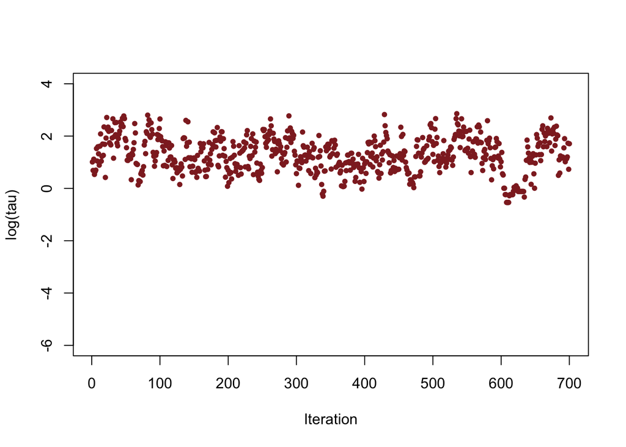

```r
params_cp <- as.data.frame(extract(fit_cp, permuted=FALSE))
names(params_cp) <- gsub("chain:1.", "", names(params_cp), fixed = TRUE)
names(params_cp) <- gsub("[", ".", names(params_cp), fixed = TRUE)
names(params_cp) <- gsub("]", "", names(params_cp), fixed = TRUE)
params_cp$iter <- 1:700

plot(params_cp$iter, log(params_cp$tau), col=c_dark, pch=16, cex=0.8,
     xlab="Iteration", ylab="log(tau)", ylim=c(-6, 4))
```

Unfortunately, the resulting estimate for the mean of $log(\tau)$ is strongly biased away from the true value, here shown in grey,

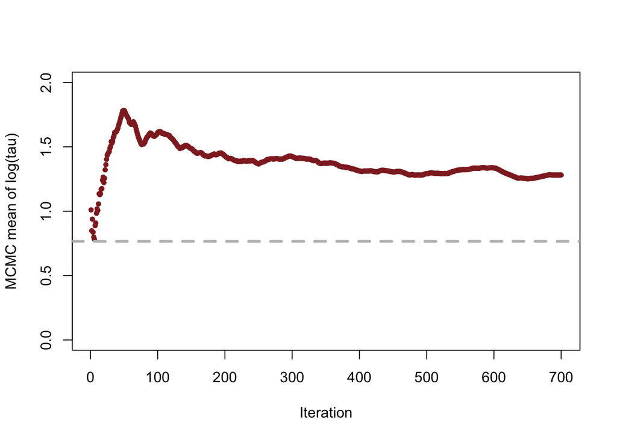

```r
running_means <- sapply(params_cp$iter, function(n) mean(log(params_cp$tau)[1:n]))

plot(params_cp$iter, running_means, col=c_dark, pch=16, cex=0.8, ylim=c(0, 2),
    xlab="Iteration", ylab="MCMC mean of log(tau)")
abline(h=0.7657852, col="grey", lty="dashed", lwd=3)
```

Hamiltonian Monte Carlo, however, is not so oblivious to these issues as almost 2% of the iterations in our lone Markov chain ended with a divergence

```r
divergent <- get_sampler_params(fit_cp, inc_warmup=FALSE)[[1]][,'divergent__']
sum(divergent)
```

```
## [1] 12
```

```r
sum(divergent) / 700
```

```
## [1] 0.01714286
```

Even with a single short chain these divergences are able to identity the bias and advise skepticism of any resulting MCMC estimators.

Additionally, because the divergent transitions, here shown here in green, tend to be located near the pathologies we can use them to identify the location of the problematic neighborhoods in parameter space,

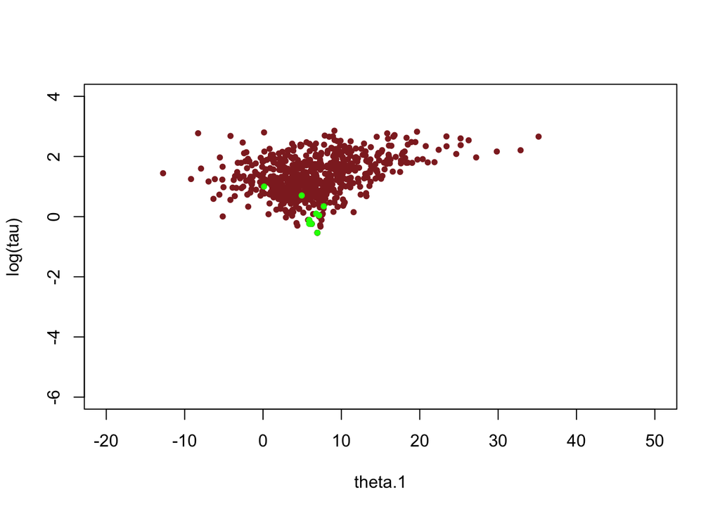

```r
params_cp$divergent <- divergent

div_params_cp <- params_cp[params_cp$divergent == 1,]
nondiv_params_cp <- params_cp[params_cp$divergent == 0,]

plot(nondiv_params_cp$theta.1, log(nondiv_params_cp$tau),
     col=c_dark, pch=16, cex=0.8, xlab="theta.1", ylab="log(tau)",
     xlim=c(-20, 50), ylim=c(-6,4))
points(div_params_cp$theta.1, log(div_params_cp$tau),
       col="green", pch=16, cex=0.8)
```

In this case the divergences are clustering at small values of $\tau$ where the hierarchical distribution, and hence all of the group-level $\theta_{n}$, are squeezed together. Indeed, this is exactly the funnel geometry infamous to hierarchical models, except cut off at the neck where the Hamiltonian Markov chain is unable to explore further and instead diverges.

## A Safer, Longer Markov Chain

Aware of the potential insensitivity of split $\hat{R}$ on single short chains, we recommend always running multiple chains as long as possible to have the best chance to observe any obstructions to geometric ergodicity. Because it is not always possible to run long chains for complex models, however, divergences are an incredibly powerful diagnostic for biased MCMC estimation.

With divergences already indicating a problem for our centered implementation of the Eight Schools model, let’s run a much longer chain to see how the problems more obviously manifest,

```r
fit_cp80 <- stan(file='eight_schools_cp.stan', data=input_data,
                 iter=11000, warmup=1000, chains=1, seed=483892929)
```

```
##
##
## Chain 1, Iteration:     1 / 11000 [  0%]  (Warmup)
## Chain 1, Iteration:  1001 / 11000 [  9%]  (Sampling)
## Chain 1, Iteration:  2100 / 11000 [ 19%]  (Sampling)
## Chain 1, Iteration:  3200 / 11000 [ 29%]  (Sampling)
## Chain 1, Iteration:  4300 / 11000 [ 39%]  (Sampling)
## Chain 1, Iteration:  5400 / 11000 [ 49%]  (Sampling)
## Chain 1, Iteration:  6500 / 11000 [ 59%]  (Sampling)
## Chain 1, Iteration:  7600 / 11000 [ 69%]  (Sampling)
## Chain 1, Iteration:  8700 / 11000 [ 79%]  (Sampling)
## Chain 1, Iteration:  9800 / 11000 [ 89%]  (Sampling)
## Chain 1, Iteration: 10900 / 11000 [ 99%]  (Sampling)
## Chain 1, Iteration: 11000 / 11000 [100%]  (Sampling)
##  Elapsed Time: 0.085932 seconds (Warm-up)
##                0.552165 seconds (Sampling)
##                0.638097 seconds (Total)
```

Even with so many more iterations, split $\hat{R}$ does not indicate any serious issues,

```r
print(fit_cp80)
```

```
## Inference for Stan model: eight_schools_cp.
## 1 chains, each with iter=11000; warmup=1000; thin=1;
## post-warmup draws per chain=10000, total post-warmup draws=10000.
##
##            mean se_mean   sd   2.5%    25%    50%    75% 97.5% n_eff Rhat
## mu         4.36    0.12 3.40  -2.31   2.19   4.39   6.76 10.98   799    1
## tau        3.82    0.17 3.26   0.67   1.51   2.91   5.06 12.28   376    1
## theta[1]   6.23    0.17 5.62  -3.15   2.54   5.64   8.99 19.59  1136    1
## theta[2]   4.93    0.13 4.77  -4.52   2.12   4.78   7.87 14.68  1315    1
## theta[3]   3.86    0.13 5.37  -8.12   0.86   4.00   7.16 13.68  1644    1
## theta[4]   4.72    0.14 4.94  -5.18   1.73   4.62   7.71 14.43  1327    1
## theta[5]   3.55    0.13 4.81  -6.97   0.80   3.65   6.76 12.18  1302    1
## theta[6]   3.96    0.13 4.88  -6.40   1.16   3.94   6.97 13.22  1524    1
## theta[7]   6.37    0.17 5.28  -2.58   2.81   5.92   9.14 18.79  1007    1
## theta[8]   4.82    0.12 5.33  -5.63   1.79   4.72   7.80 15.77  1961    1
## lp__     -14.94    0.47 6.14 -26.56 -19.39 -15.07 -10.27 -3.98   170    1
##
## Samples were drawn using NUTS(diag_e) at Wed Jan 18 21:27:49 2017.
## For each parameter, n_eff is a crude measure of effective sample size,
## and Rhat is the potential scale reduction factor on split chains (at
## convergence, Rhat=1).
```

We really need to be incorporating multiple chains for split $\hat{R}$ to be effective. Still, note that the effective sample size per iteration has drastically fallen, indicating that we are exploring less efficiently the longer we run. This odd behavior is a clear sign that something problematic is afoot.

The trace plots are more indicative of the underlying pathologies, showing the chain occasionally “sticking” as it approaches small values of $\tau$, exactly where we saw the divergences concentrating,

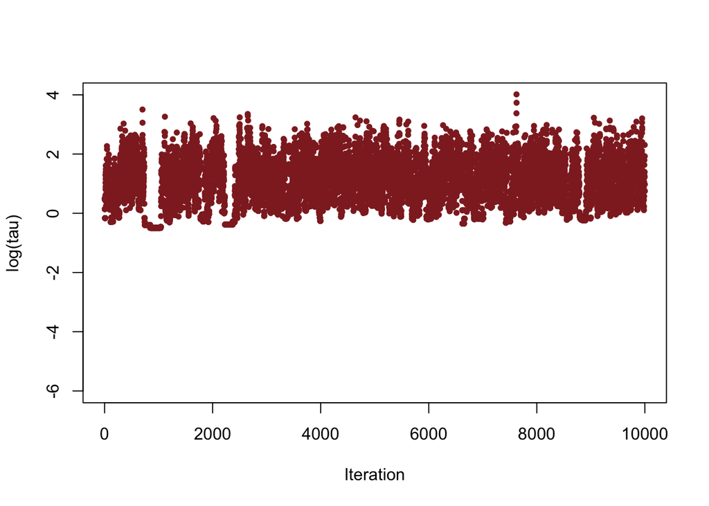

```r
params_cp80 <- as.data.frame(extract(fit_cp80, permuted=FALSE))
names(params_cp80) <- gsub("chain:1.", "", names(params_cp80), fixed = TRUE)
names(params_cp80) <- gsub("[", ".", names(params_cp80), fixed = TRUE)
names(params_cp80) <- gsub("]", "", names(params_cp80), fixed = TRUE)
params_cp80$iter <- 1:10000

plot(params_cp80$iter, log(params_cp80$tau), col=c_dark, pch=16, cex=0.8,
     xlab="Iteration", ylab="log(tau)", ylim=c(-6, 4))
```

These sticky intervals induce severe oscillations in the MCMC estimators early on, until they seem to finally settle into biased values,

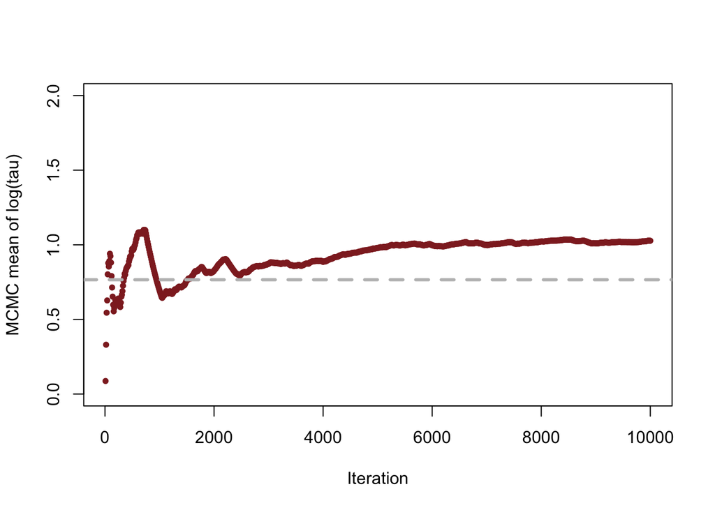

```r
running_means_cp80 <- sapply(1:1000, function(n) mean(log(params_cp80$tau)[1:(10*n)]))

plot(10*(1:1000), running_means_cp80, col=c_dark, pch=16, cex=0.8, ylim=c(0, 2),
    xlab="Iteration", ylab="MCMC mean of log(tau)")
abline(h=0.7657852, col="grey", lty="dashed", lwd=3)
```

In fact the sticky intervals are the Markov chain trying to correct the biased exploration. If we ran the chain even longer then it would eventually get stuck again and drag the MCMC estimator down towards the true value. Given an infinite number of iterations this delicate balance asymptotes to the true expectation as we’d expect given the consistency guarantee of MCMC. Stopping the after any finite number of iterations, however, destroys this balance and leaves us with a significant bias.

```r
divergent <- get_sampler_params(fit_cp80, inc_warmup=FALSE)[[1]][,'divergent__']
sum(divergent)
```

```
## [1] 299
```

```r
sum(divergent) / 10000
```

```
## [1] 0.0299
```

and the increased sampling really allows us to see the truncated funnel geometry of the Markov chain,

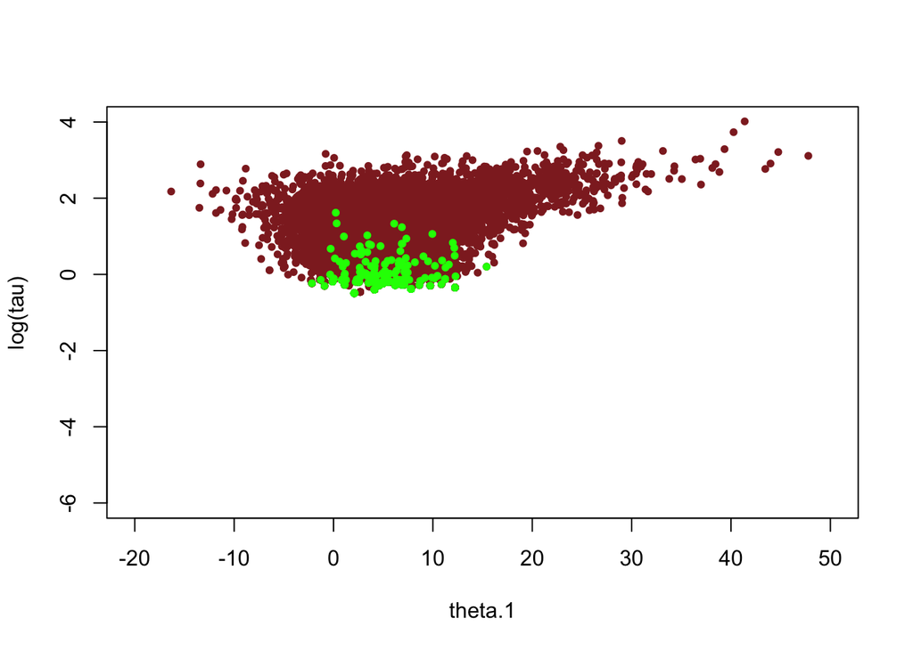

```r
params_cp80$divergent <- divergent

div_params_cp <- params_cp80[params_cp80$divergent == 1,]
nondiv_params_cp <- params_cp80[params_cp80$divergent == 0,]

plot(nondiv_params_cp$theta.1, log(nondiv_params_cp$tau),
     col=c_dark, pch=16, cex=0.8, xlab="theta.1", ylab="log(tau)",
     xlim=c(-20, 50), ylim=c(-6,4))
points(div_params_cp$theta.1, log(div_params_cp$tau),
       col="green", pch=16, cex=0.8)
```

## Avoiding Divergences By Adjusting Stan’s Adaptation Routine

Divergences in Hamiltonian Monte Carlo arise when the Hamiltonian transition encounters regions of extremely large curvature, such as the neck of the funnel seen above. We can control how strongly this curvature effects the Hamiltonian Markov chain, however, by adjusting the step size, $\epsilon$.

In Stan the step size is tuned automatically during warm up, but we can coerce smaller step sizes by tweaking the configuration of Stan’s adaptation routine.  
In particular, we can increase the `adapt_delta` parameter from its default value of 0.8 closer to its maximum value of 1.

```r
fit_cp85 <- stan(file='eight_schools_cp.stan', data=input_data,
                 iter=11000, warmup=1000, chains=1, seed=483892929,
                 control=list(adapt_delta=0.85))
```

```
##
##
## Chain 1, Iteration:     1 / 11000 [  0%]  (Warmup)
## Chain 1, Iteration:  1001 / 11000 [  9%]  (Sampling)
## Chain 1, Iteration:  2100 / 11000 [ 19%]  (Sampling)
## Chain 1, Iteration:  3200 / 11000 [ 29%]  (Sampling)
## Chain 1, Iteration:  4300 / 11000 [ 39%]  (Sampling)
## Chain 1, Iteration:  5400 / 11000 [ 49%]  (Sampling)
## Chain 1, Iteration:  6500 / 11000 [ 59%]  (Sampling)
## Chain 1, Iteration:  7600 / 11000 [ 69%]  (Sampling)
## Chain 1, Iteration:  8700 / 11000 [ 79%]  (Sampling)
## Chain 1, Iteration:  9800 / 11000 [ 89%]  (Sampling)
## Chain 1, Iteration: 10900 / 11000 [ 99%]  (Sampling)
## Chain 1, Iteration: 11000 / 11000 [100%]  (Sampling)
##  Elapsed Time: 0.074234 seconds (Warm-up)
##                0.589023 seconds (Sampling)
##                0.663257 seconds (Total)
```

```r
fit_cp90 <- stan(file='eight_schools_cp.stan', data=input_data,
                 iter=11000, warmup=1000, chains=1, seed=483892929,
                 control=list(adapt_delta=0.90))
```

```
##
##
## Chain 1, Iteration:     1 / 11000 [  0%]  (Warmup)
## Chain 1, Iteration:  1001 / 11000 [  9%]  (Sampling)
## Chain 1, Iteration:  2100 / 11000 [ 19%]  (Sampling)
## Chain 1, Iteration:  3200 / 11000 [ 29%]  (Sampling)
## Chain 1, Iteration:  4300 / 11000 [ 39%]  (Sampling)
## Chain 1, Iteration:  5400 / 11000 [ 49%]  (Sampling)
## Chain 1, Iteration:  6500 / 11000 [ 59%]  (Sampling)
## Chain 1, Iteration:  7600 / 11000 [ 69%]  (Sampling)
## Chain 1, Iteration:  8700 / 11000 [ 79%]  (Sampling)
## Chain 1, Iteration:  9800 / 11000 [ 89%]  (Sampling)
## Chain 1, Iteration: 10900 / 11000 [ 99%]  (Sampling)
## Chain 1, Iteration: 11000 / 11000 [100%]  (Sampling)
##  Elapsed Time: 0.100319 seconds (Warm-up)
##                0.771391 seconds (Sampling)
##                0.87171 seconds (Total)
```

```r
fit_cp95 <- stan(file='eight_schools_cp.stan', data=input_data,
                 iter=11000, warmup=1000, chains=1, seed=483892929,
                 control=list(adapt_delta=0.95))
```

```
##
##
## Chain 1, Iteration:     1 / 11000 [  0%]  (Warmup)
## Chain 1, Iteration:  1001 / 11000 [  9%]  (Sampling)
## Chain 1, Iteration:  2100 / 11000 [ 19%]  (Sampling)
## Chain 1, Iteration:  3200 / 11000 [ 29%]  (Sampling)
## Chain 1, Iteration:  4300 / 11000 [ 39%]  (Sampling)
## Chain 1, Iteration:  5400 / 11000 [ 49%]  (Sampling)
## Chain 1, Iteration:  6500 / 11000 [ 59%]  (Sampling)
## Chain 1, Iteration:  7600 / 11000 [ 69%]  (Sampling)
## Chain 1, Iteration:  8700 / 11000 [ 79%]  (Sampling)
## Chain 1, Iteration:  9800 / 11000 [ 89%]  (Sampling)
## Chain 1, Iteration: 10900 / 11000 [ 99%]  (Sampling)
## Chain 1, Iteration: 11000 / 11000 [100%]  (Sampling)
##  Elapsed Time: 0.114487 seconds (Warm-up)
##                0.934464 seconds (Sampling)
##                1.04895 seconds (Total)
```

```r
fit_cp99 <- stan(file='eight_schools_cp.stan', data=input_data,
                 iter=11000, warmup=1000, chains=1, seed=483892929,
                 control=list(adapt_delta=0.99))
```

```
##
##
## Chain 1, Iteration:     1 / 11000 [  0%]  (Warmup)
## Chain 1, Iteration:  1001 / 11000 [  9%]  (Sampling)
## Chain 1, Iteration:  2100 / 11000 [ 19%]  (Sampling)
## Chain 1, Iteration:  3200 / 11000 [ 29%]  (Sampling)
## Chain 1, Iteration:  4300 / 11000 [ 39%]  (Sampling)
## Chain 1, Iteration:  5400 / 11000 [ 49%]  (Sampling)
## Chain 1, Iteration:  6500 / 11000 [ 59%]  (Sampling)
## Chain 1, Iteration:  7600 / 11000 [ 69%]  (Sampling)
## Chain 1, Iteration:  8700 / 11000 [ 79%]  (Sampling)
## Chain 1, Iteration:  9800 / 11000 [ 89%]  (Sampling)
## Chain 1, Iteration: 10900 / 11000 [ 99%]  (Sampling)
## Chain 1, Iteration: 11000 / 11000 [100%]  (Sampling)
##  Elapsed Time: 0.286872 seconds (Warm-up)
##                1.19084 seconds (Sampling)
##                1.47771 seconds (Total)
```

With the increasing `adapt_delta`, and decreasing step size,

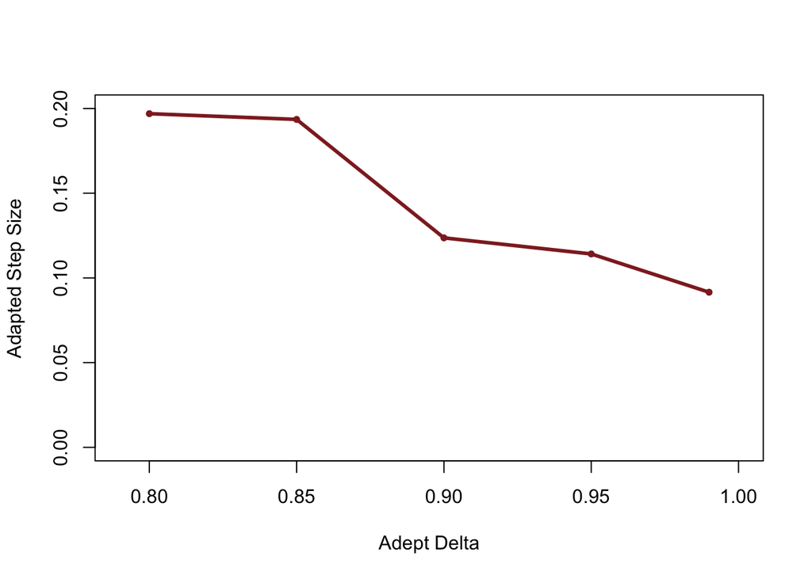

```r
adapt_delta=c(0.80, 0.85, 0.90, 0.95, 0.99)
step_scan=c(get_sampler_params(fit_cp80, inc_warmup=FALSE)[[1]][,'stepsize__'][1],
            get_sampler_params(fit_cp85, inc_warmup=FALSE)[[1]][,'stepsize__'][1],
            get_sampler_params(fit_cp90, inc_warmup=FALSE)[[1]][,'stepsize__'][1],
            get_sampler_params(fit_cp95, inc_warmup=FALSE)[[1]][,'stepsize__'][1],
            get_sampler_params(fit_cp99, inc_warmup=FALSE)[[1]][,'stepsize__'][1])

plot(adapt_delta, step_scan, xlab="Adept Delta", ylab="Adapted Step Size",
     xlim=c(0.79, 1.0), ylim=c(0, 0.2), col=c_dark, type="l", lwd=3)
points(adapt_delta, step_scan, col=c_dark, pch=16, cex=0.8)
```

we would expect the divergences to decrease, but counter-intuitively they remain constant!

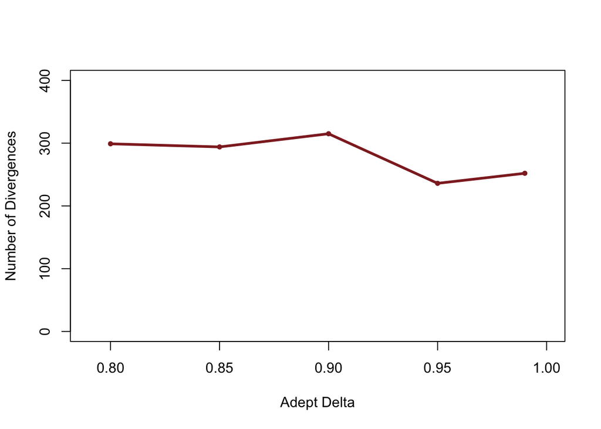

```r
div_scan=c(sum(params_cp80$divergent),
           sum(get_sampler_params(fit_cp85, inc_warmup=FALSE)[[1]][,'divergent__']),
           sum(get_sampler_params(fit_cp90, inc_warmup=FALSE)[[1]][,'divergent__']),
           sum(get_sampler_params(fit_cp95, inc_warmup=FALSE)[[1]][,'divergent__']),
           sum(get_sampler_params(fit_cp99, inc_warmup=FALSE)[[1]][,'divergent__']))

plot(adapt_delta, div_scan, xlab="Adept Delta", ylab="Number of Divergences",
     xlim=c(0.79, 1.0), ylim=c(0, 400), col=c_dark, type="l", lwd=3)
points(adapt_delta, div_scan, col=c_dark, pch=16, cex=0.8)
```

What’s going on? Well the smaller we decrease the step size the more the Hamiltonian Markov chain can explore the neck of the funnel. Indeed the marginal posterior distribution for $\log \tau$ stretches further and further towards negative values with the decreasing step size,

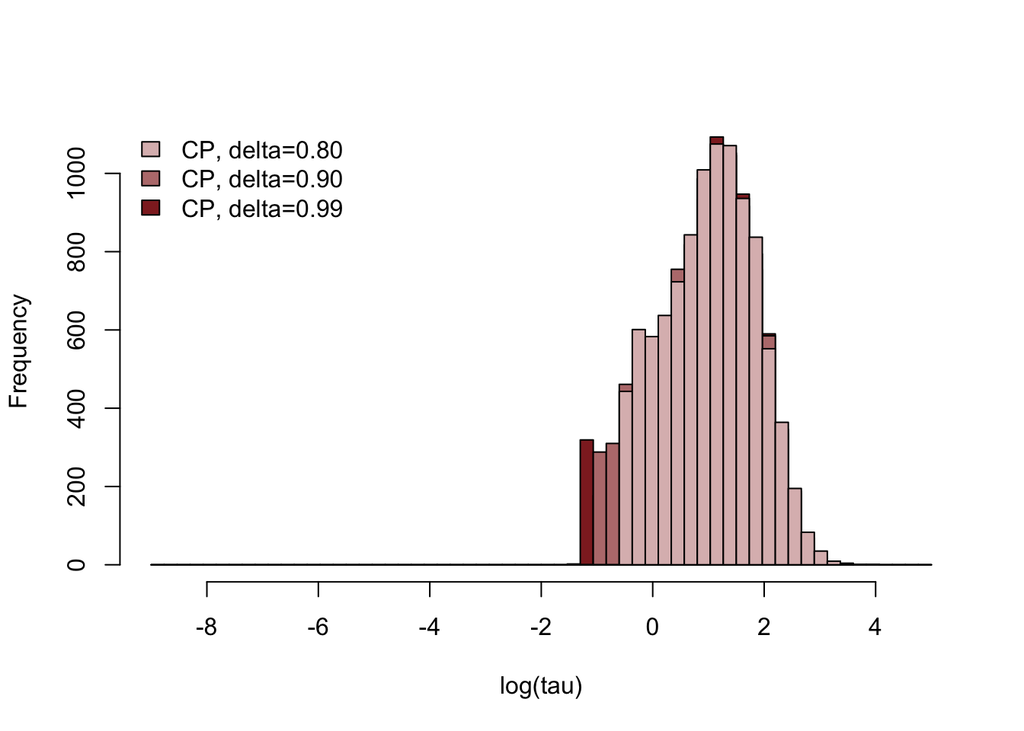

```r
common_breaks=14 * (0:60) / 60 - 9

p_cp80 <- hist(log(extract(fit_cp80)$tau), breaks=common_breaks, plot=FALSE)
p_cp90 <- hist(log(extract(fit_cp90)$tau), breaks=common_breaks, plot=FALSE)
p_cp99 <- hist(log(extract(fit_cp99)$tau), breaks=common_breaks, plot=FALSE)

plot(p_cp99, col=c_dark, main="", xlab="log(tau)")
plot(p_cp90, col=c_mid, add=T)
plot(p_cp80, col=c_light, add=T)
legend("topleft", c("CP, delta=0.80", "CP, delta=0.90", "CP, delta=0.99"),
       fill=c(c_light, c_mid, c_dark), bty="n")
```

But the deeper into the funnel we explore the more highly-curved and pathological it becomes. The chain with the largest `adapt_delta` pushes deeper into the neck of the funnel but still ends up diverging when it probes too far,

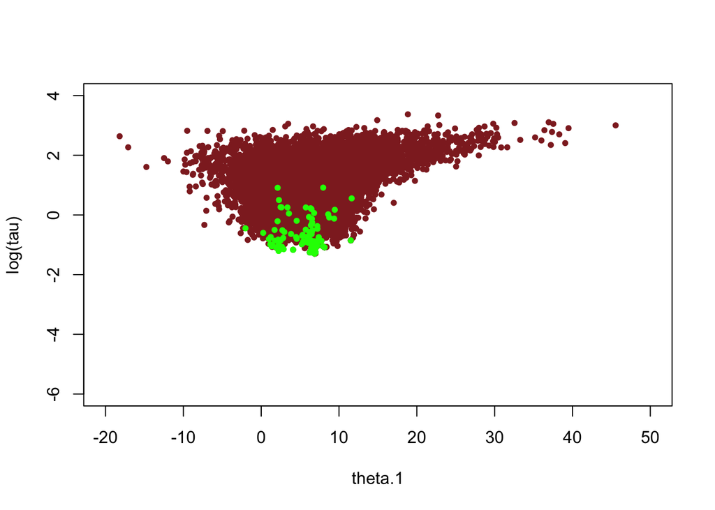

```r
params_cp99 <- as.data.frame(extract(fit_cp99, permuted=FALSE))
names(params_cp99) <- gsub("chain:1.", "", names(params_cp99), fixed = TRUE)
names(params_cp99) <- gsub("[", ".", names(params_cp99), fixed = TRUE)
names(params_cp99) <- gsub("]", "", names(params_cp99), fixed = TRUE)

divergent <- get_sampler_params(fit_cp99, inc_warmup=FALSE)[[1]][,'divergent__']
params_cp99$divergent <- divergent

div_params_cp99 <- params_cp99[params_cp99$divergent == 1,]
nondiv_params_cp99 <- params_cp99[params_cp99$divergent == 0,]

plot(nondiv_params_cp99$theta.1, log(nondiv_params_cp99$tau),
     xlab="theta.1", ylab="log(tau)", xlim=c(-20, 50), ylim=c(-6,4),
     col=c_dark, pch=16, cex=0.8)
points(div_params_cp99$theta.1, log(div_params_cp99$tau),
       col="green", pch=16, cex=0.8)
```

The improved exploration is evident when comparing the samples, here with no distinction between divergent and non-divergent, from the nominal chain and the the `adapt_delta=0.99` chain,

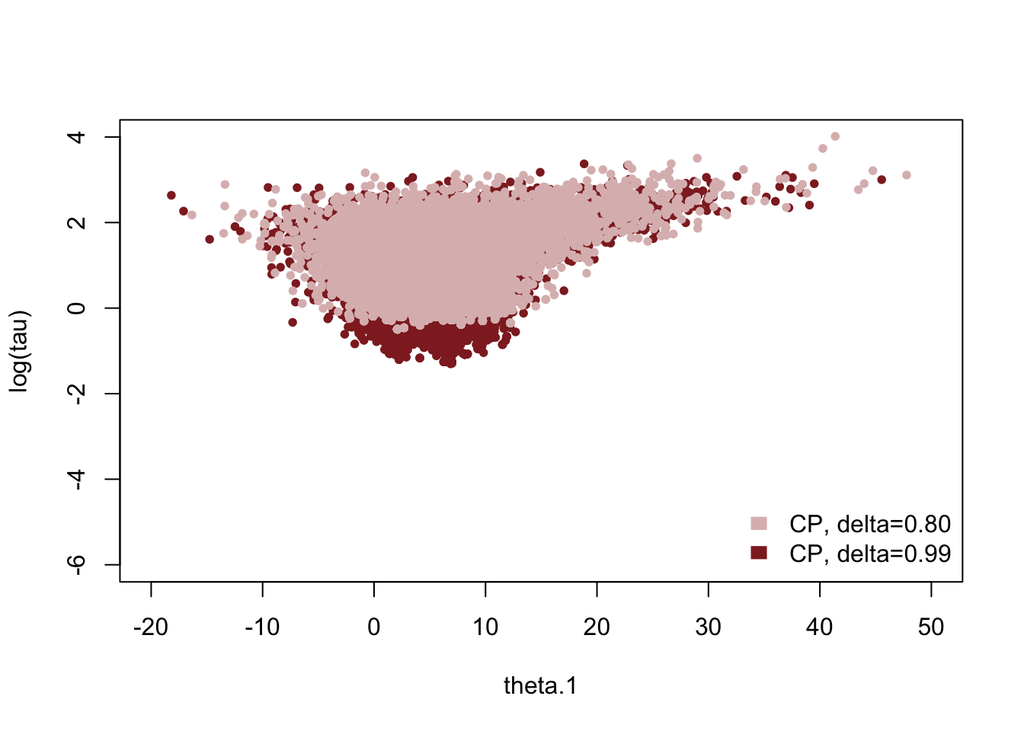

```r
plot(params_cp99$theta.1, log(params_cp99$tau),
     xlab="theta.1", ylab="log(tau)", xlim=c(-20, 50), ylim=c(-6,4),
     col=c_dark, pch=16, cex=0.8)
points(params_cp80$theta.1, log(params_cp80$tau), col=c_light, pch=16, cex=0.8)
legend("bottomright", c("CP, delta=0.80", "CP, delta=0.99"),
       fill=c(c_light, c_dark), border="white", bty="n")
```

That said, the superior exploration given by decreasing the step size does reduce the bias of the resulting MCMC estimators,

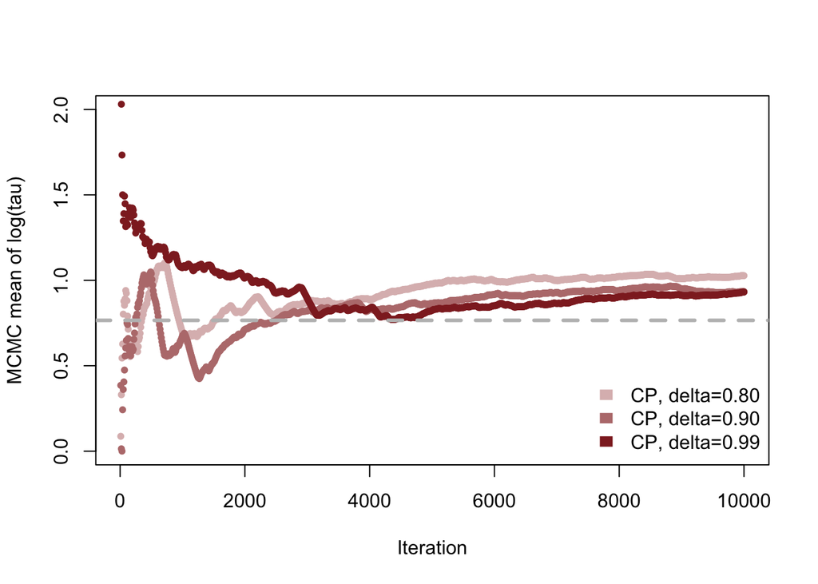

```r
params_cp90 <- as.data.frame(extract(fit_cp90, permuted=FALSE))
names(params_cp90) <- gsub("chain:1.", "", names(params_cp90), fixed = TRUE)
names(params_cp90) <- gsub("[", ".", names(params_cp90), fixed = TRUE)
names(params_cp90) <- gsub("]", "", names(params_cp90), fixed = TRUE)

running_means_cp90 <- sapply(1:1000, function(n) mean(log(params_cp90$tau)[1:(10*n)]))
running_means_cp99 <- sapply(1:1000, function(n) mean(log(params_cp99$tau)[1:(10*n)]))

plot(10*(1:1000), running_means_cp80, col=c_light, pch=16, cex=0.8, ylim=c(0, 2),
    xlab="Iteration", ylab="MCMC mean of log(tau)")
points(10*(1:1000), running_means_cp90, col=c_mid, pch=16, cex=0.8)
points(10*(1:1000), running_means_cp99, col=c_dark, pch=16, cex=0.8)
abline(h=0.7657852, col="grey", lty="dashed", lwd=3)
legend("bottomright", c("CP, delta=0.80", "CP, delta=0.90", "CP, delta=0.99"),
       fill=c(c_light, c_mid, c_dark), border="white", bty="n")
```

Even for the extreme setting of `adapt_delta=0.99`, however, the bias does not completely vanish.

# A Non-Centered Eight Schools Implementation

Although reducing the step size improves exploration, it only reveals the true extent the pathology in the centered implementation. Fortunately, there is another way to implement hierarchical models that does not suffer from the same pathologies.

In a non-centered parameterization we do not try to fit the group-level parameters directly, rather we fit a latent Gaussian variable from which we can recover the group-level parameters with a scaling and translation,

$$\mu \sim \mathcal{N}(0, 5)$$

$$\tau \sim \text{Half-Cauchy}(0, 5)$$

$$\tilde{\theta}_{n} \sim \mathcal{N}(0, 1)$$

Because we are actively sampling from different parameters, we should expect, and indeed observe, a very different posterior distribution. Note that formally a non-centered implementation is not actually a reparamterization of the centered implementation, but the terms “centered parameterization” and “non-centered parameterization” have persisted in the literature and so I will use them here.

The Stan program for the non-centered parameterization is almost as simple as that for the centered parameterization,

```r
writeLines(readLines("eight_schools_ncp.stan"))
```

```
## data {
##   int<lower=0> J;
##   real y[J];
##   real<lower=0> sigma[J];
## }
##
## parameters {
##   real mu;
##   real<lower=0> tau;
##   real theta_tilde[J];
## }
##
## transformed parameters {
##   real theta[J];
##   for (j in 1:J)
##     theta[j] = mu + tau * theta_tilde[j];
## }
##
## model {
##   mu ~ normal(0, 5);
##   tau ~ cauchy(0, 5);
##   theta_tilde ~ normal(0, 1);
##   y ~ normal(theta, sigma);
## }
```

Running the new model in Stan,

```r
fit_ncp80 <- stan(file='eight_schools_ncp.stan', data=input_data,
                  iter=11000, warmup=1000, chains=1, seed=483892929)
```

```
##
##
## Chain 1, Iteration:     1 / 11000 [  0%]  (Warmup)
## Chain 1, Iteration:  1001 / 11000 [  9%]  (Sampling)
## Chain 1, Iteration:  2100 / 11000 [ 19%]  (Sampling)
## Chain 1, Iteration:  3200 / 11000 [ 29%]  (Sampling)
## Chain 1, Iteration:  4300 / 11000 [ 39%]  (Sampling)
## Chain 1, Iteration:  5400 / 11000 [ 49%]  (Sampling)
## Chain 1, Iteration:  6500 / 11000 [ 59%]  (Sampling)
## Chain 1, Iteration:  7600 / 11000 [ 69%]  (Sampling)
## Chain 1, Iteration:  8700 / 11000 [ 79%]  (Sampling)
## Chain 1, Iteration:  9800 / 11000 [ 89%]  (Sampling)
## Chain 1, Iteration: 10900 / 11000 [ 99%]  (Sampling)
## Chain 1, Iteration: 11000 / 11000 [100%]  (Sampling)
##  Elapsed Time: 0.043541 seconds (Warm-up)
##                0.327047 seconds (Sampling)
##                0.370588 seconds (Total)
```

we see that the effective sample size per iteration has drastically improved,

```r
print(fit_ncp80)
```

```
## Inference for Stan model: eight_schools_ncp.
## 1 chains, each with iter=11000; warmup=1000; thin=1;
## post-warmup draws per chain=10000, total post-warmup draws=10000.
##
##                 mean se_mean   sd   2.5%   25%   50%   75% 97.5% n_eff
## mu              4.46    0.03 3.30  -2.22  2.33  4.52  6.66 10.88 10000
## tau             3.49    0.04 3.07   0.11  1.21  2.70  4.93 11.39  6083
## theta_tilde[1]  0.31    0.01 1.00  -1.63 -0.38  0.30  0.99  2.26 10000
## theta_tilde[2]  0.09    0.01 0.95  -1.79 -0.55  0.10  0.73  1.92 10000
## theta_tilde[3] -0.08    0.01 0.97  -1.95 -0.75 -0.07  0.58  1.80 10000
## theta_tilde[4]  0.06    0.01 0.94  -1.81 -0.57  0.06  0.69  1.92 10000
## theta_tilde[5] -0.16    0.01 0.94  -2.00 -0.79 -0.16  0.46  1.71 10000
## theta_tilde[6] -0.06    0.01 0.94  -1.90 -0.69 -0.07  0.55  1.80 10000
## theta_tilde[7]  0.36    0.01 0.96  -1.55 -0.28  0.38  1.03  2.20 10000
## theta_tilde[8]  0.08    0.01 0.97  -1.85 -0.58  0.08  0.75  1.97 10000
## theta[1]        6.21    0.06 5.73  -3.28  2.80  5.61  8.83 19.70  8639
## theta[2]        5.00    0.05 4.63  -4.10  2.17  4.87  7.71 14.80 10000
## theta[3]        3.97    0.05 5.13  -7.05  1.21  4.20  7.09 13.35  8729
## theta[4]        4.77    0.05 4.74  -4.86  1.96  4.80  7.63 14.25 10000
## theta[5]        3.69    0.05 4.59  -6.51  1.01  3.94  6.66 12.04 10000
## theta[6]        4.17    0.05 4.74  -5.90  1.40  4.31  7.15 13.15 10000
## theta[7]        6.36    0.05 5.04  -2.10  3.10  5.88  8.94 18.04 10000
## theta[8]        4.94    0.06 5.27  -5.52  1.86  4.87  7.88 15.99  7832
## lp__           -6.97    0.04 2.35 -12.44 -8.28 -6.62 -5.28 -3.37  3747
##                Rhat
## mu                1
## tau               1
## theta_tilde[1]    1
## theta_tilde[2]    1
## theta_tilde[3]    1
## theta_tilde[4]    1
## theta_tilde[5]    1
## theta_tilde[6]    1
## theta_tilde[7]    1
## theta_tilde[8]    1
## theta[1]          1
## theta[2]          1
## theta[3]          1
## theta[4]          1
## theta[5]          1
## theta[6]          1
## theta[7]          1
## theta[8]          1
## lp__              1
##
## Samples were drawn using NUTS(diag_e) at Wed Jan 18 21:35:41 2017.
## For each parameter, n_eff is a crude measure of effective sample size,
## and Rhat is the potential scale reduction factor on split chains (at
## convergence, Rhat=1).
```

and the trace plots no longer show any “stickyness”,

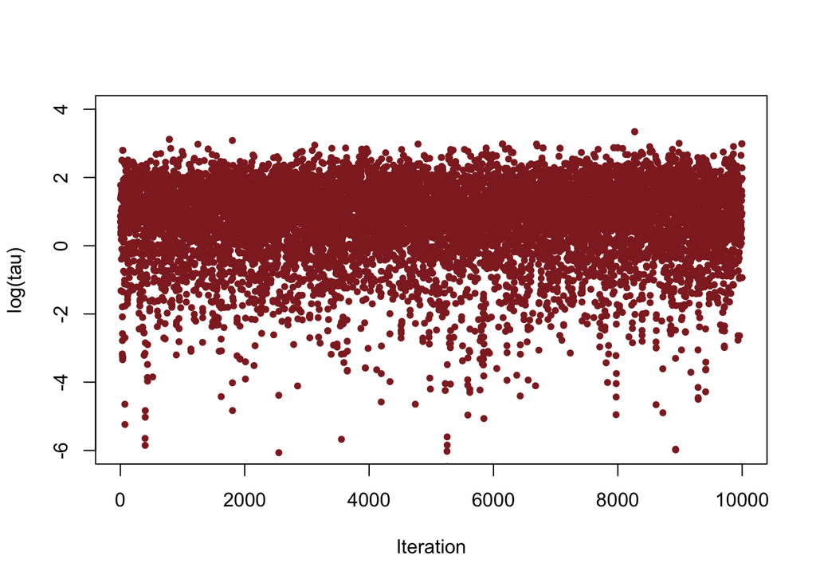

```r
params_ncp80 <- as.data.frame(extract(fit_ncp80, permuted=FALSE))
names(params_ncp80) <- gsub("chain:1.", "", names(params_ncp80), fixed = TRUE)
names(params_ncp80) <- gsub("[", ".", names(params_ncp80), fixed = TRUE)
names(params_ncp80) <- gsub("]", "", names(params_ncp80), fixed = TRUE)
params_ncp80$iter <- 1:10000

plot(params_ncp80$iter, log(params_ncp80$tau), col=c_dark, pch=16, cex=0.8,
     xlab="Iteration", ylab="log(tau)", ylim=c(-6, 4))
```

Very rarely, however, we do still see a divergence,

```r
divergent <- get_sampler_params(fit_ncp80, inc_warmup=FALSE)[[1]][,'divergent__']
sum(divergent)
```

```
## [1] 26
```

```r
sum(divergent) / 10000
```

```
## [1] 0.0026
```

but interestingly they do not seem concentrate anywhere in parameter space,

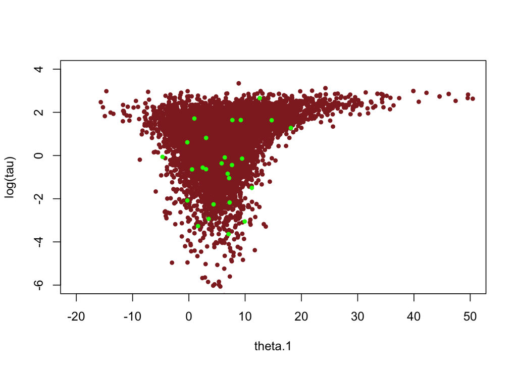

```r
divergent <- get_sampler_params(fit_ncp80, inc_warmup=FALSE)[[1]][,'divergent__']
params_ncp80$divergent <- divergent

div_params_ncp <- params_ncp80[params_ncp80$divergent == 1,]
nondiv_params_ncp <- params_ncp80[params_ncp80$divergent == 0,]

plot(nondiv_params_ncp$theta.1, log(nondiv_params_ncp$tau),
     xlab="theta.1", ylab="log(tau)", xlim=c(-20, 50), ylim=c(-6,4),
     col=c_dark, pch=16, cex=0.8)
points(div_params_ncp$theta.1, log(div_params_ncp$tau),
       col="green", pch=16, cex=0.8)
```

We can fix these scarce divergences by decreasing the step size,

```r
fit_ncp90 <- stan(file='eight_schools_ncp.stan', data=input_data,
                  iter=11000, warmup=1000, chains=1, seed=483892929,
                  control=list(adapt_delta=0.90))
```

```
##
##
## Chain 1, Iteration:     1 / 11000 [  0%]  (Warmup)
## Chain 1, Iteration:  1001 / 11000 [  9%]  (Sampling)
## Chain 1, Iteration:  2100 / 11000 [ 19%]  (Sampling)
## Chain 1, Iteration:  3200 / 11000 [ 29%]  (Sampling)
## Chain 1, Iteration:  4300 / 11000 [ 39%]  (Sampling)
## Chain 1, Iteration:  5400 / 11000 [ 49%]  (Sampling)
## Chain 1, Iteration:  6500 / 11000 [ 59%]  (Sampling)
## Chain 1, Iteration:  7600 / 11000 [ 69%]  (Sampling)
## Chain 1, Iteration:  8700 / 11000 [ 79%]  (Sampling)
## Chain 1, Iteration:  9800 / 11000 [ 89%]  (Sampling)
## Chain 1, Iteration: 10900 / 11000 [ 99%]  (Sampling)
## Chain 1, Iteration: 11000 / 11000 [100%]  (Sampling)
##  Elapsed Time: 0.051267 seconds (Warm-up)
##                0.567449 seconds (Sampling)
##                0.618716 seconds (Total)
```

which finally gives us a long chain with no divergences,

```r
divergent <- get_sampler_params(fit_ncp90, inc_warmup=FALSE)[[1]][,'divergent__']
sum(divergent)
```

```
## [1] 0
```

The more agreeable geometry of the non-centered implementation allows the Markov chain to explore deep into the neck of the funnel, capturing even the smallest values of $\tau$ that are consistent with the measurements,

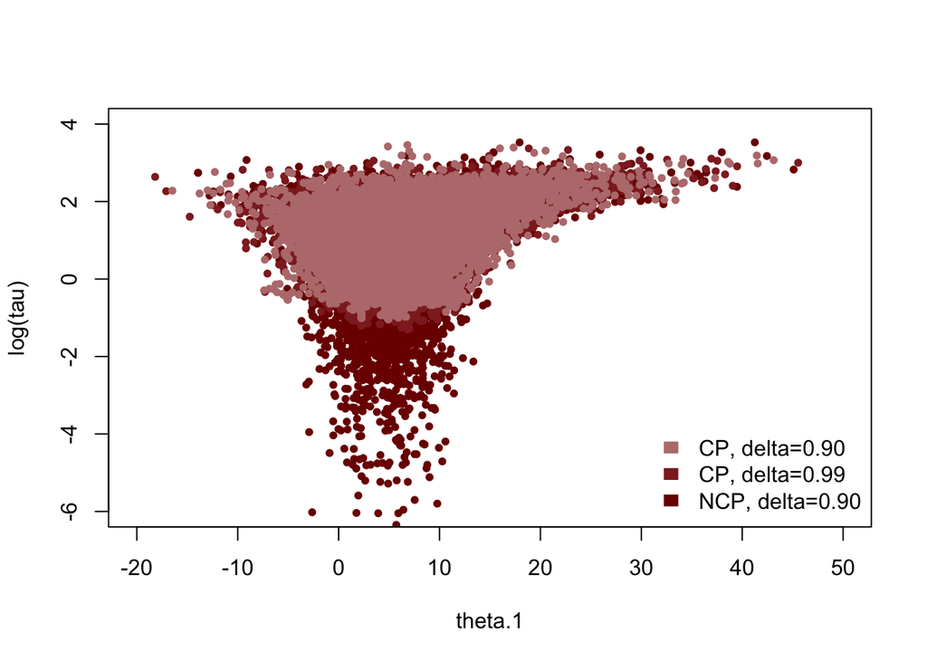

```r
params_ncp90 <- as.data.frame(extract(fit_ncp90, permuted=FALSE))
names(params_ncp90) <- gsub("chain:1.", "", names(params_ncp90), fixed = TRUE)
names(params_ncp90) <- gsub("[", ".", names(params_ncp90), fixed = TRUE)
names(params_ncp90) <- gsub("]", "", names(params_ncp90), fixed = TRUE)

plot(params_ncp90$theta.1, log(params_ncp90$tau),
     xlab="theta.1", ylab="log(tau)", xlim=c(-20, 50), ylim=c(-6,4),
     col=c_dark_highlight, pch=16, cex=0.8)
points(params_cp99$theta.1, log(params_cp99$tau), col=c_dark, pch=16, cex=0.8)
points(params_cp90$theta.1, log(params_cp90$tau), col=c_mid, pch=16, cex=0.8)
legend("bottomright", c("CP, delta=0.90", "CP, delta=0.99", "NCP, delta=0.90"),
       fill=c(c_mid, c_dark, c_dark_highlight), border="white", bty="n")
```

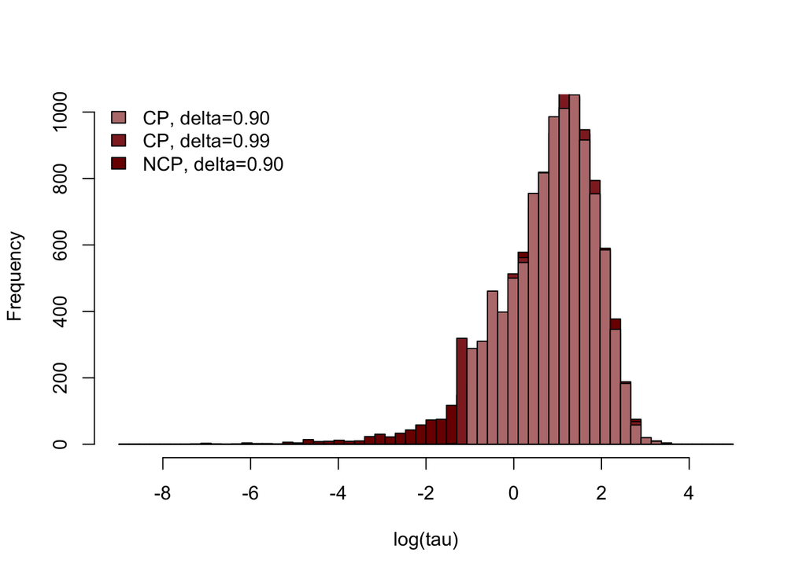

```r
p_ncp90 <- hist(log(params_ncp90$tau), breaks=common_breaks, plot=FALSE)

plot(p_ncp90, col=c_dark_highlight, main="", xlab="log(tau)")
plot(p_cp99, col=c_dark, add=T)
plot(p_cp90, col=c_mid, add=T)

legend("topleft", c("CP, delta=0.90", "CP, delta=0.99", "NCP, delta=0.90"),
       fill=c(c_mid, c_dark, c_dark_highlight), bty="n")
```

Consequently, MCMC estimators from the non-centered chain rapidly converge towards their true expectation values,

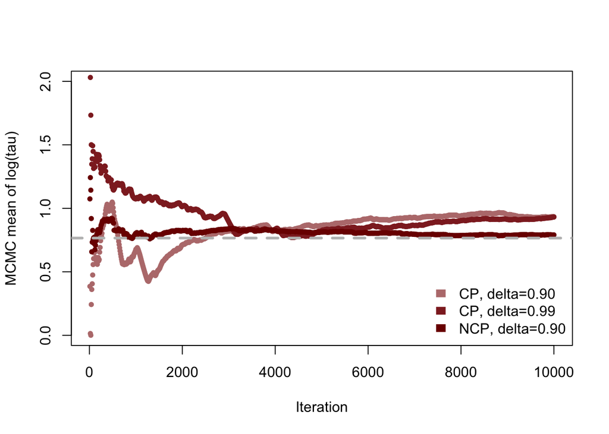

```r
running_means_ncp <- sapply(1:1000, function(n) mean(log(params_ncp90$tau)[1:(10*n)]))

plot(10*(1:1000), running_means_cp90, col=c_mid, pch=16, cex=0.8, ylim=c(0, 2),
    xlab="Iteration", ylab="MCMC mean of log(tau)")
points(10*(1:1000), running_means_cp99, col=c_dark, pch=16, cex=0.8)
points(10*(1:1000), running_means_ncp, col=c_dark_highlight, pch=16, cex=0.8)
abline(h=0.7657852, col="grey", lty="dashed", lwd=3)
legend("bottomright", c("CP, delta=0.90", "CP, delta=0.99", "NCP, delta=0.90"),
       fill=c(c_mid, c_dark, c_dark_highlight), border="white", bty="n")
```

# Discussion

By analyzing the Eight Schools model we have seen that, when the data are sparse, hierarchical models implemented with a centered parameterization impede the geometric ergodicity of most Markov transitions. The ultimate importance of the resulting bias, however, depends on the application.

If we are interested in the behavior of $\log \tau$ then this bias is huge and will devastate to the quality of any inferences drawn from the fit. Often, however, one is not interested in the behavior of $\log \tau$ but rather the behavior of $\tau$. When we transform to the linear scale the pathological region of the posterior is compressed into a small volume and the the biases somewhat mediated,

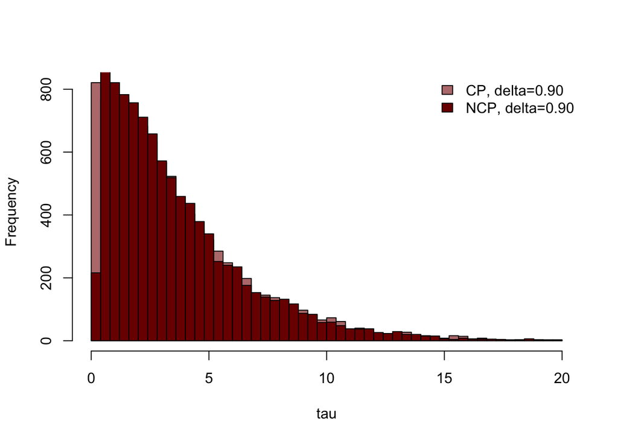

```r
breaks=20 * (0:50) / 50

p_cp <- hist(params_cp90$tau[params_cp90$tau < 20], breaks=breaks, plot=FALSE)
p_ncp <- hist(params_ncp90$tau[params_ncp90$tau < 20], breaks=breaks, plot=FALSE)

plot(p_ncp, col=c_mid, main="", xlab="tau")
plot(p_cp, col=c_dark_highlight, add=T)
legend("topright", c("CP, delta=0.90", "NCP, delta=0.90"),
       fill=c(c_mid, c_dark_highlight), bty="n")
```

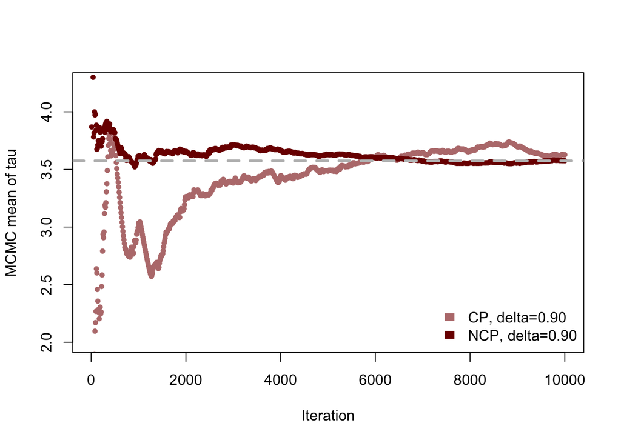

```r
running_means_cp <- sapply(1:1000, function(n) mean(params_cp90$tau[1:(10*n)]))
running_means_ncp <- sapply(1:1000, function(n) mean(params_ncp90$tau[1:(10*n)]))

plot(10*(1:1000), running_means_cp, col=c_mid, pch=16, cex=0.8, ylim=c(2, 4.25),
    xlab="Iteration", ylab="MCMC mean of tau")
points(10*(1:1000), running_means_ncp, col=c_dark_highlight, pch=16, cex=0.8)
abline(h=3.575019, col="grey", lty="dashed", lwd=3)
legend("bottomright", c("CP, delta=0.90", "NCP, delta=0.90"),
       fill=c(c_mid, c_dark_highlight), border="white", bty="n")
```

At least the bias is not as obvious as it was on the logarithmic scale.

This mediation also affects how the bias propagates to other parameters in the model. When we average over the hierarchical prior, the small bias of $\tau$ the marginal posterior for the group-level parameters to be narrower than they should be,

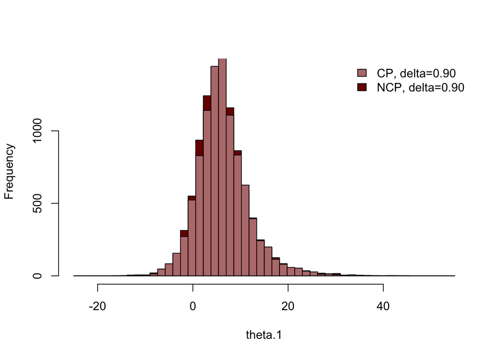

```r
breaks=80 * (0:50) / 50 - 25

p_cp <- hist(params_cp90$theta.1, breaks=breaks, plot=FALSE)
p_ncp <- hist(params_ncp90$theta.1, breaks=breaks, plot=FALSE)

plot(p_ncp, col=c_dark_highlight, main="", xlab="theta.1")
plot(p_cp, col=c_mid, add=T)

legend("topright", c("CP, delta=0.90", "NCP, delta=0.90"),
       fill=c(c_mid, c_dark_highlight), bty="n")
```

This narrowness does not affect the accuracy of the mean of the group-level parameters,

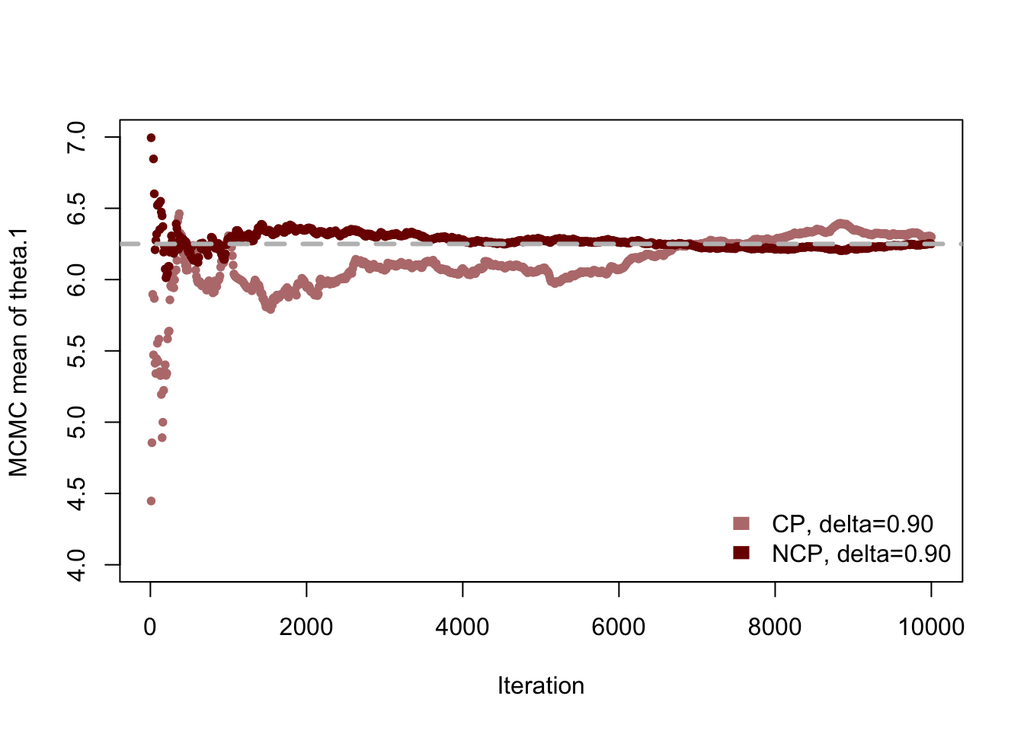

```r
running_means_cp <- sapply(1:1000, function(n) mean(params_cp90$theta.1[1:(10*n)]))
running_means_ncp <- sapply(1:1000, function(n) mean(params_ncp90$theta.1[1:(10*n)]))

plot(10*(1:1000), running_means_cp, col=c_mid, pch=16, cex=0.8, ylim=c(4, 7),
    xlab="Iteration", ylab="MCMC mean of theta.1")
points(10*(1:1000), running_means_ncp, col=c_dark_highlight, pch=16, cex=0.8)
abline(h=6.250004, col="grey", lty="dashed", lwd=3)
legend("bottomright", c("CP, delta=0.90", "NCP, delta=0.90"),
       fill=c(c_mid, c_dark_highlight), border="white", bty="n")
```

but it does systematically underestimate the variance, at least for a long time,

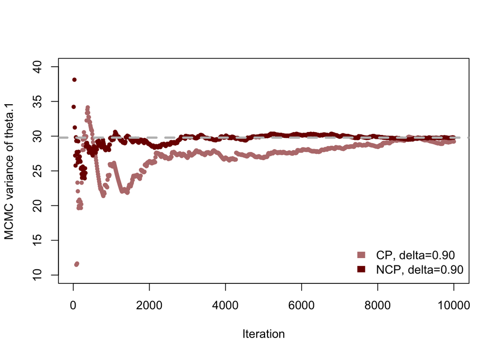

```r
running_means_cp <- sapply(1:1000, function(n) var(params_cp90$theta.1[1:(10*n)]))
running_means_ncp <- sapply(1:1000, function(n) var(params_ncp90$theta.1[1:(10*n)]))

plot(10*(1:1000), running_means_cp, col=c_mid, pch=16, cex=0.8, ylim=c(10, 40),
    xlab="Iteration", ylab="MCMC variance of theta.1")
points(10*(1:1000), running_means_ncp, col=c_dark_highlight, pch=16, cex=0.8)
abline(h=29.78573, col="grey", lty="dashed", lwd=3)
legend("bottomright", c("CP, delta=0.90", "NCP, delta=0.90"),
       fill=c(c_mid, c_dark_highlight), border="white", bty="n")
```

In practice this bias can be hard to observe if the Markov chain is slow and the MCMC estimators are noisy, as is common when using older MCMC algorithms like Random Walk Metropolis and Gibbs samplers.

Ultimately, identifying the breakdown of geometric ergodicity for a given Markov transition and target distribution indicates only that there is a bias, not how significant that bias will be. The precise significance of any such bias depends not only on the structure of the model but also on the details of how that model will be applied in practice. Sometimes an analysis taking these factors into account can quantify the significance of the bias and potentially deem it acceptable. These analyses, however, are extremely subtle, challenging, and time-consuming. It is almost always easier to modify the model to restore geometric ergodicity and unbiased MCMC estimation.

Regardless, divergences are an incredibly powerful diagnostic for the breakdown of geometric ergodicity and hence critical guidance for best implementing our models in practice.

# References

Betancourt, Michael, and Mark Girolami. 2015. “Hamiltonian Monte Carlo for Hierarchical Models.” In *Current Trends in Bayesian Methodology with Applications*, edited by Umesh Singh Dipak K. Dey and A. Loganathan. Chapman & Hall/CRC Press.

Rubin, Donald B. 1981. “Estimation in Parallel Randomized Experiments.” *Journal of Educational and Behavioral Statistics* 6 (4): 377–401.